# Batman

> Πάνος Λουρίδας, Αναπληρωτής Καθηγητής  
> Τμήμα Διοικητικής Επιστήμης και Τεχνολογίας  
> Οικονομικό Πανεπιστήμιο Αθηνών  
> louridas@aueb.gr
- Η βασική βιβλιοθήκη για τη δημιουργία γραφημάτων στην Python είναι το [matplotlib](https://matplotlib.org/).
- Με το matplotlib μπορούμε να ρυθμίσουμε σε λεπτομέρεια την εμφάνισή του γραφήματός μας ώστε να φτιάξουμε (περίπου) οποιοδήποτε γράφημα θέλουμε.
- Για να πούμε όμως την αλήθεια, μπορεί να χρειαστεί αρκετή προσπάθεια για να φτιάξουμε κομψά γραφήματα.

```python
import matplotlib
import matplotlib.pyplot as plt
import numpy as np
```

- Ο πιο πρόσφορος τρόπος να αλληλεπιδράσουμε με το matplotlib είναι μέσω της διεπαφής `pyplot`.
- To `pyplot` μας δίνει τη δυνατότητα να προσθέσουμε συστατικά στοιχεία το γράφημά μας σε ένα σχετικά υψηλό επίπεδο αφαίρεσης.

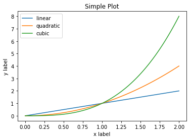

```python
x = np.linspace(0, 2, 100)

plt.plot(x, x, label='linear')
plt.plot(x, x**2, label='quadratic')
plt.plot(x, x**3, label='cubic')

plt.xlabel('x label')
plt.ylabel('y label')

plt.title("Simple Plot")

plt.legend()
```

- Το `pyplot` δεν είναι ο μοναδικός τρόπος να δουλέψουμε με το matplotlib.
- Μπορούμε να εργαστούμε χρησιμοποιώντας την αντικειμενοστραφή προγραμματιστική διεπαφή του (Application Programming Interface, API), όπου όλα τα στοιχεία του γραφήματος δημιουργούνται ως στιγμιότυπα (instances) κλάσεων (classes).
- Έτσι, το παραπάνω παράδειγμα μπορούμε να το φτιάξουμε και όπως στη συνέχεια, όπου δουλεύουμε με αντικείμενα `Figure` και`Axes`.

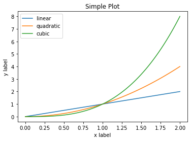

```python
fig = plt.figure()  # an empty figure with no axes

axes = fig.gca()
axes.plot(x, x, label='linear')

axes.plot(x, x**2, label='quadratic')
axes.plot(x, x**3, label='cubic')

axes.set_xlabel('x label')
axes.set_ylabel('y label')

axes.set_title("Simple Plot")

axes.legend()
```

- Η γενικότερη εμφάνιση ενός γραφήματος με το matplotlib μπορεί να ρυθμιστεί μέσω *στυλ*.
- Το matplotlib διαθέτει έναν αριθμό από προκαθορισμένα στυλ.

```python
print(plt.style.available)
len(plt.style.available)
```

[output not shown]

```
28
```

- Μπορούμε να δούμε πώς αλλάζει το ίδιο γράφημα χρησιμοποιώντας διαφορετικά στυλ.

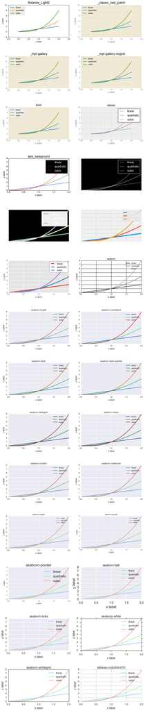

```python
plt.figure(figsize=(12, 130))
plt.subplots_adjust(hspace=0.6)

x = np.linspace(0, 2, 100)

nstyles = len(plt.style.available)
for i, style in enumerate(plt.style.available):
    plt.subplot(nstyles, 2, i + 1)
    plt.style.use(style)
    plt.plot(x, x, label='linear')
    plt.plot(x, x**2, label='quadratic')
    plt.plot(x, x**3, label='cubic')

    plt.xlabel('x label')
    plt.ylabel('y label')

    plt.title(style)

    plt.legend()
```

- Το καλό (και ο μπελάς) με το matplotlib είναι ότι μπορούμε να ρυθμίσουμε τα πάντα.
- Για παράδειγμα, έστω ότι θέλουμε να ρυθμίσουμε το σημείο εμφάνισης του υπομνήματος (legend).
- Αυτό μπορούμε να το καθορίσουμε με την παράμετρο `loc`, η οποία μπορεί να πάρει τις παρακάτω τιμές:

| Location String | Location Code |
| --- | --- |
| 'best' | 0 |
| 'upper right' | 1 |
| 'upper left' | 2 |
| 'lower left' | 3 |
| 'lower right' | 4 |
| 'right' | 5 |
| 'center left' | 6 |
| 'center right' | 7 |
| 'lower center' | 8 |
| 'upper center' | 9 |
| 'center' | 10 |

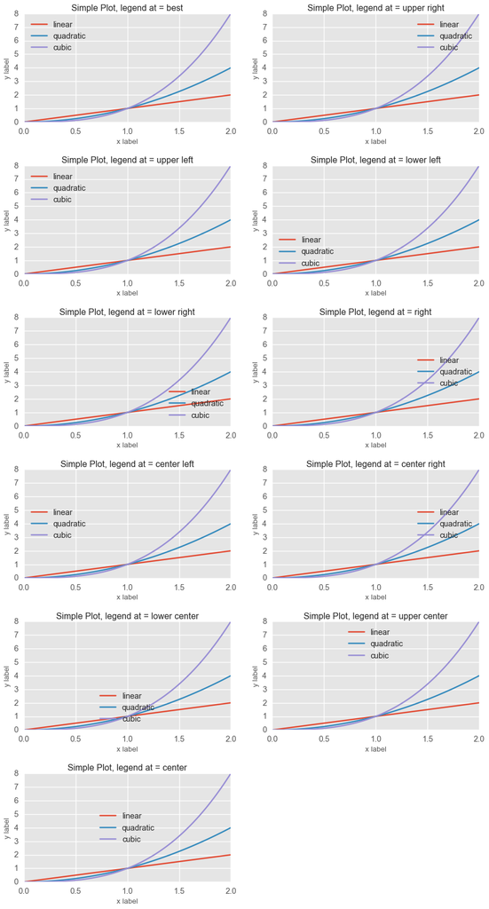

```python
legend_loc_str = [
    'best',
    'upper right',
    'upper left',
    'lower left',
    'lower right',
    'right',
    'center left',
    'center right',
    'lower center',
    'upper center',
    'center'
]

plt.style.use('ggplot')
plt.figure(figsize=(12, 24))
plt.subplots_adjust(hspace=0.4)

x = np.linspace(0, 2, 100)

for i, loc in enumerate(legend_loc_str):
    plt.subplot(6, 2, i + 1)
    plt.plot(x, x, label='linear')
    plt.plot(x, x**2, label='quadratic')
    plt.plot(x, x**3, label='cubic')

    plt.xlabel('x label')
    plt.ylabel('y label')

    plt.title("Simple Plot, legend at = " + loc)

    plt.legend(loc=loc)
```

- Όπως είπαμε, αντί για το `pyplot` μπορούμε να χρησιμοποιήσουμε την αντικειμενοστραφή διεπαφή του matplotlib.
- Άρα μπορούμε να κατασκευάσουμε την προηγούμενη εικόνα και όπως στη συνέχεια.

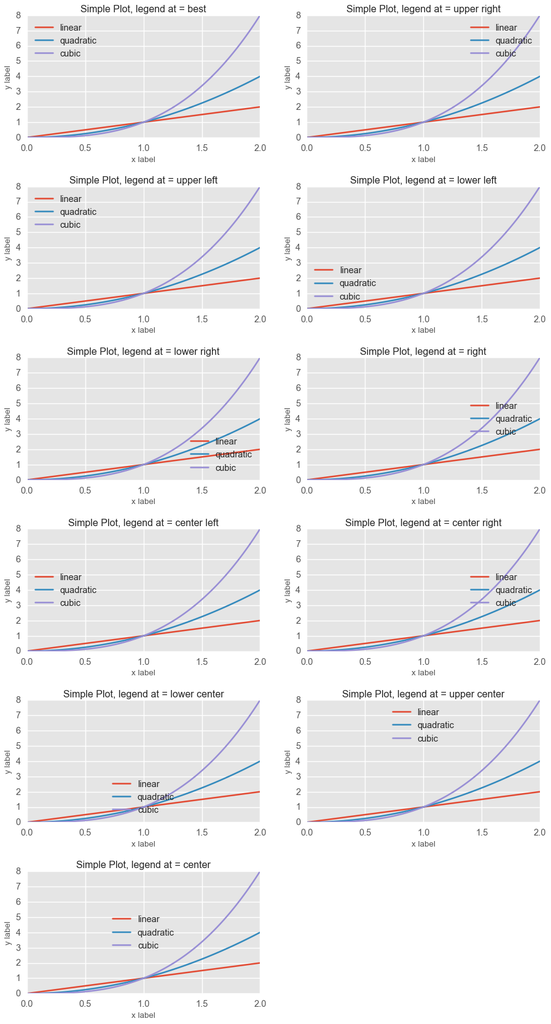

```python
figure = plt.figure(figsize=(12, 24))
figure.subplots_adjust(hspace=0.4)

x = np.linspace(0, 2, 100)

for i, loc in enumerate(legend_loc_str):
    ax = figure.add_subplot(6, 2, i + 1)
    ax.plot(x, x, label='linear')
    ax.plot(x, x**2, label='quadratic')
    ax.plot(x, x**3, label='cubic')

    ax.set_xlabel('x label')
    ax.set_ylabel('y label')

    ax.set_title("Simple Plot, legend at = " + loc)

    ax.legend(loc=loc)
```

- Μια άλλη παράμετρος που μπορούμε να ρυθμίσουμε με το matplolib είναι το χρώμα με το οποίο θα εμφανίζονται τα στοιχεία της εικόνας.
- Το matplotlib μπορεί να χρησιμοποιήσει πληθώρα χρωμάτων με διαφορετικούς τρόπους.
- Προς το παρόν ας σταθούμε στα βασικά οκτώ χρώματα που χρησιμοποιεί:
  - `b`: `blue`
  - `g`: `green`
  - `r`: `red`
  - `c`: `cyan`
  - `m`: `magenta`
  - `y`: `yellow`
  - `k`: `black`
  - `w`: `white`
- Ας σχεδιάσουμε την παρακάτω συνάρτηση, κάθε φορά με ένα διαφορετικό χρώμα:

$$ y = x \sin\frac{1}{x} $$

- Η συνάρτηση αυτή, για το λόγο που θα δούμε ευθύς αμέσως, ονομάζεται συνάρτηση Batman.

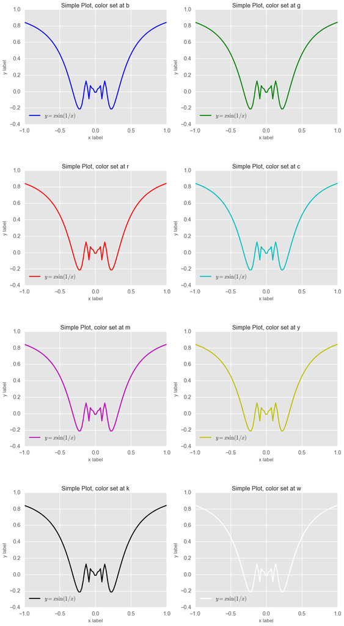

```python
colors = [
    'b',
    'g',
    'r',
    'c',
    'm',
    'y',
    'k',
    'w'
]

figure = plt.figure(figsize=(12, 24))
figure.subplots_adjust(hspace=0.4)

x = np.linspace(-1, 1, 100)
y = x * np.sin(1 / x)

for i, color in enumerate(colors):
    ax = figure.add_subplot(4, 2, i + 1)
    ax.plot(x, y, color=color, label=r'$y = x \sin(1/x)$')

    ax.set_xlabel('x label')
    ax.set_ylabel('y label')

    ax.set_title("Simple Plot, color set at " + color)

    ax.legend(loc='best')
```